# 13. Temporal Data I

## Temporal ordering

```r
page_views
```

```
## # A tibble: 3,660 x 5
##    item   year month   day views
##    <chr> <dbl> <dbl> <dbl> <dbl>
##  1 Apple  2019    12    28  2458
##  2 Apple  2019    12    29  2659
##  3 Apple  2019    12    30  2849
##  4 Apple  2019    12    31  2589
##  5 Apple  2020     1     1  2579
##  6 Apple  2020     1     2  3078
##  7 Apple  2020     1     3  3034
##  8 Apple  2020     1     4  2820
##  9 Apple  2020     1     5  2939
## 10 Apple  2020     1     6  3172
## # … with 3,650 more rows
```

The time variables are given the way we recommended in Chapter 3, with individual columns for year, month, and day. Here, our dataset is already ordered (within each item type) from the earliest records to the dateset. If this were not the case, because all of our variables are stored as numbers, we could use the `arrange` function to sort by year, followed by month, followed by year, to get the same ordering.

How could we show the change in page views over time for a particular variable? One approach is to use the `row_number` function to add a numeric column running down the dataset. Here is an example of a line plot using the row number approach:

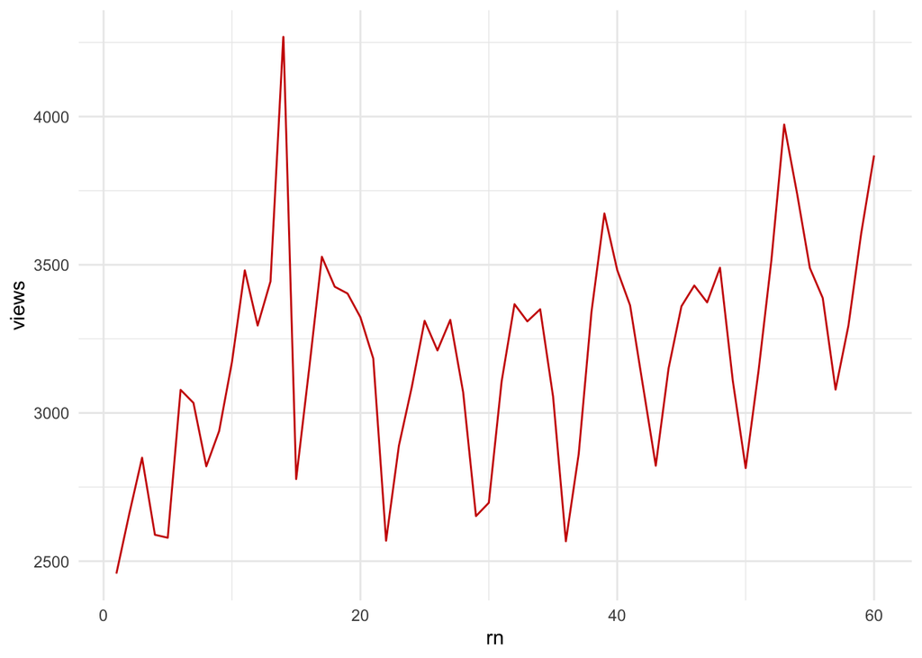

```r
page_views %>%
  filter(item %in% c("Apple")) %>%
  mutate(rn = row_number()) %>%
  ggplot() +
    geom_line(aes(x = rn, y = views), color = "red3")
```

In this case, the plot is not too bad. The x-axis corresponds to the day number, and in many applications that may be exactly what we need. Notice, though, that we cannot tell anything from the plot about exactly what days of the year are being represented. Also, note that this only works because the data are uniformaly sampled (one observation each day) and there is no missing data.

Another way to work with dates is to convert the data to a fractional year format. Here, the months and days are added to form a fractional day. A quick way to do this is to compute:

$$year\_frac = year + \frac{month - 1}{12} + \frac{day - 1}{12 \cdot 31}$$

We are subtracting one from the month and day so, for example, on a date such as 1 July 2020 (halfway through the year) we have the fractional year equal to `2020.5`. We could make this even more exact by accounting for the fact that some months have fewer than 31 days, but even with February in our range of data the results work well:

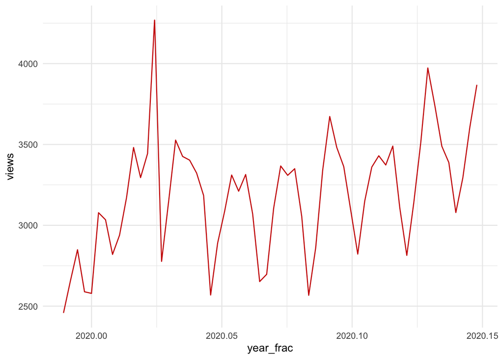

```r
page_views %>%
  filter(item %in% c("Apple")) %>%
  mutate(year_frac = year + (month - 1) / 12 + (day - 1) / (12 * 31)) %>%
  ggplot() +
    geom_line(aes(x = year_frac, y = views), color = "red3")
```

This revised visualization improves on several aspects of the original plot. For one thing, we can roughly see exactly what dates correspond to each data point. Also, the code will work fine regardless of whether the data are sorted, evenly distributed, or contain any missing values. As a down-side, the axis labels take some explaining. We can extend the same approach to working with time data. For example, if we also had the (24-hour) time of our data points the formula would become:

$$year\_frac = year + \frac{month - 1}{12} + \frac{day - 1}{12 \cdot 31} + + \frac{hour - 1}{24 \cdot 12 \cdot 31}$$

If we are only interested in the time since a specific event, say the start of an experiment, we can use the same approach but take the difference relative to a specific fractional year.

Fractional times have a number of important applications. Fractional times are convenient because they can represent an arbitrarily precise date or date-time with an ordinary number. This means that they can be used in other models and applications without any special treatment. They may require different model *assumptions*, but at least the code should work with minimal effort. However, particularly when we want to create nice publishable visualizations, it can be useful to work with specific functions for manipulating dates and times.

## Date objects

Most of the variables that we have worked with so far are either characters (`chr`) or numbers (`dbl`). Dates are in some ways like numbers: the have a natural ordering, we can talk about the difference between two numbers, and it makes sense to color and plot them on a continuous scale. However, they do have some unique properties, particularly when we want to extract information such as the day of the week from a date, that require a unique data type. To create a date object in R, we can use the function `make_date`, passing in a variable for the year, month, and day.

```r
page_views %>%
  filter(item %in% c("Apple")) %>%
  mutate(date = make_date(year, month, day))
```

```
## # A tibble: 60 x 6
##    item   year month   day views date
##    <chr> <dbl> <dbl> <dbl> <dbl> <date>
##  1 Apple  2019    12    28  2458 2019-12-28
##  2 Apple  2019    12    29  2659 2019-12-29
##  3 Apple  2019    12    30  2849 2019-12-30
##  4 Apple  2019    12    31  2589 2019-12-31
##  5 Apple  2020     1     1  2579 2020-01-01
##  6 Apple  2020     1     2  3078 2020-01-02
##  7 Apple  2020     1     3  3034 2020-01-03
##  8 Apple  2020     1     4  2820 2020-01-04
##  9 Apple  2020     1     5  2939 2020-01-05
## 10 Apple  2020     1     6  3172 2020-01-06
## # … with 50 more rows
```

Notice that the new column has a special data type: `date`. If we build a visualization using a date object, `ggplot` is able to make smart choices about how to label the axis:

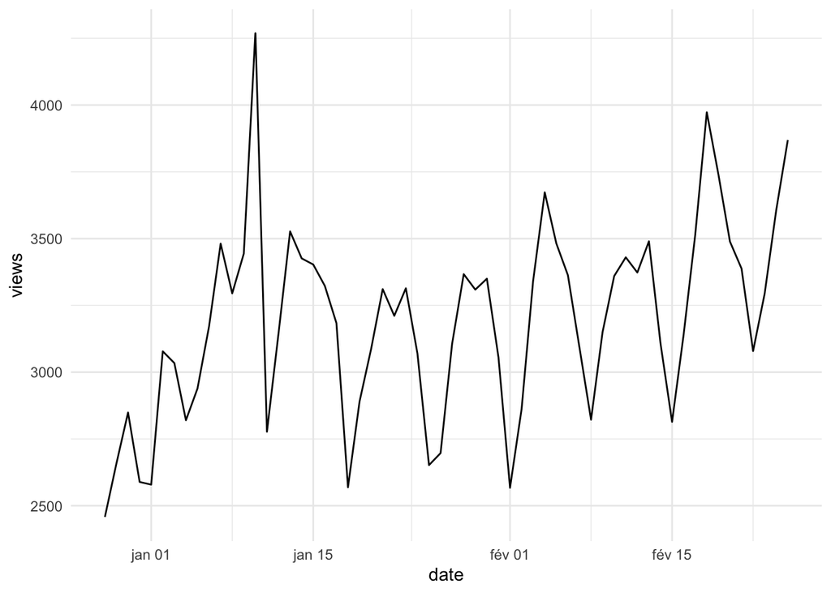

```r
page_views %>%
  filter(item %in% c("Apple")) %>%
  mutate(date = make_date(year, month, day)) %>%
  ggplot() +
    geom_line(aes(date, views))
```

Here, the algorithm decided to label each half-month. We can manually change the frequency of the labels using the `scale_x_date` and setting the `date_breaks` option. Tt is possible to describe the frequency of labels using a string. For example, here we show a label for each week:

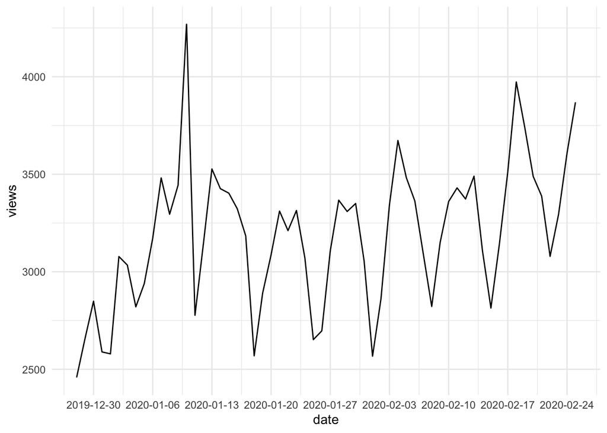

```r
page_views %>%
  filter(item %in% c("Apple")) %>%
  mutate(date = make_date(year, month, day)) %>%
  ggplot() +
    geom_line(aes(date, views)) +
    scale_x_date(date_breaks = "1 week")
```

Once we have a date object, we can also extract useful information from it. For example, the `wday` function extracts the weekday of the date. Here, we will compute the weekday using labels (`label = TRUE`, otherwise we have a numeric description of the weekday) and compute the average number of page views for each day of the week:

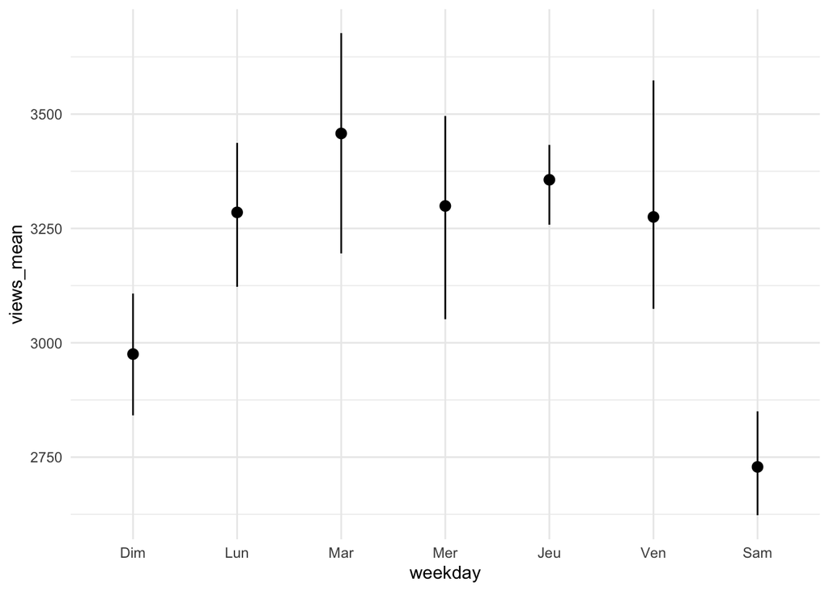

```r
page_views %>%
  filter(item %in% c("Apple")) %>%
  mutate(date = make_date(year, month, day)) %>%
  mutate(weekday = wday(date, label = TRUE)) %>%
  group_by(weekday) %>%
  summarize(sm_mean_cl_boot(views)) %>%
  ggplot() +
    geom_pointrange(
      aes(x = weekday, y = views_mean, ymin = views_ci_min, ymax = views_ci_max)
    )
```

Here we see that the number of page views is the lowest on Saturday and the number of views is highest on Tuesday. We can also use the `make_date` function to filter the dataset. For example, we can filter the dataset to only include those dates after 15 January 2020:

```r
page_views %>%
  filter(item %in% c("Apple")) %>%
  mutate(date = make_date(year, month, day)) %>%
  filter(date > make_date(2020, 1, 15))
```

```
## # A tibble: 41 x 6
##    item   year month   day views date
##    <chr> <dbl> <dbl> <dbl> <dbl> <date>
##  1 Apple  2020     1    16  3323 2020-01-16
##  2 Apple  2020     1    17  3184 2020-01-17
##  3 Apple  2020     1    18  2569 2020-01-18
##  4 Apple  2020     1    19  2890 2020-01-19
##  5 Apple  2020     1    20  3087 2020-01-20
##  6 Apple  2020     1    21  3311 2020-01-21
##  7 Apple  2020     1    22  3211 2020-01-22
##  8 Apple  2020     1    23  3314 2020-01-23
##  9 Apple  2020     1    24  3070 2020-01-24
## 10 Apple  2020     1    25  2652 2020-01-25
## # … with 31 more rows
```

Note that you can leave some of the values in the `make_date` function empty. For example, passing only the year and month. This defaults to the first day of the month. This shorthand is useful in both creating the original date object as well as when filtering the data.

## Date times

A similar approach to dates can also apply the objects that include time data. As an example, we will look at another related dataset from Wikipedia. Here, for each of the same pages as considered in the previous set, we have a record of the last 500 edits made to each page. For every edit, we have the exact second that an edit was made:

```r
page_revisions
```

```
## # A tibble: 30,415 x 10
##    item   year month   day  hour minute second user            page_size
##    <chr> <dbl> <dbl> <dbl> <dbl>  <dbl>  <dbl> <chr>               <dbl>
##  1 Apple  2020     1    16    18      5     15 Zefr                74204
##  2 Apple  2020     1    16    18      2     55 TarantinQuenti…     74263
##  3 Apple  2020     1    14    14     48     14 Zefr                74204
##  4 Apple  2020     1    14    14     41     17 DRosenbach          74230
##  5 Apple  2020     1    11    15     54     42 Zefr                74204
##  6 Apple  2020     1    11    15     22      5 Thue                74265
##  7 Apple  2020     1    11    15     21     41 Thue                74273
##  8 Apple  2020     1    11    10     53     30 Peter coxhead       73464
##  9 Apple  2020     1    11    10     17     43 Thue                73460
## 10 Apple  2019    12    31    16     29     19 Plantdrew           73093
## # … with 30,405 more rows, and 1 more variable: comment <chr>
```

Similar to the approach in the previous section, we can use the function `make_datetime` to create a date-time object. Here we will fill it in with the year, month, day, hour, minute, and second. As mentioned above, however, you can supply on the subset of precision matching your data.

```r
page_revisions %>%
  mutate(time = make_datetime(year, month, day, hour, minute, second)) %>%
  select(item, time, year, month, day, hour, minute, second)
```

```
## # A tibble: 30,415 x 8
##    item  time                 year month   day  hour minute second
##    <chr> <dttm>              <dbl> <dbl> <dbl> <dbl>  <dbl>  <dbl>
##  1 Apple 2020-01-16 18:05:15  2020     1    16    18      5     15
##  2 Apple 2020-01-16 18:02:55  2020     1    16    18      2     55
##  3 Apple 2020-01-14 14:48:14  2020     1    14    14     48     14
##  4 Apple 2020-01-14 14:41:17  2020     1    14    14     41     17
##  5 Apple 2020-01-11 15:54:42  2020     1    11    15     54     42
##  6 Apple 2020-01-11 15:22:05  2020     1    11    15     22      5
##  7 Apple 2020-01-11 15:21:41  2020     1    11    15     21     41
##  8 Apple 2020-01-11 10:53:30  2020     1    11    10     53     30
##  9 Apple 2020-01-11 10:17:43  2020     1    11    10     17     43
## 10 Apple 2019-12-31 16:29:19  2019    12    31    16     29     19
## # … with 30,405 more rows
```

One piece of information that we know about each edit is the size of the page, in bytes. Looking at this over time shows when large additions and deletions were made to each record.

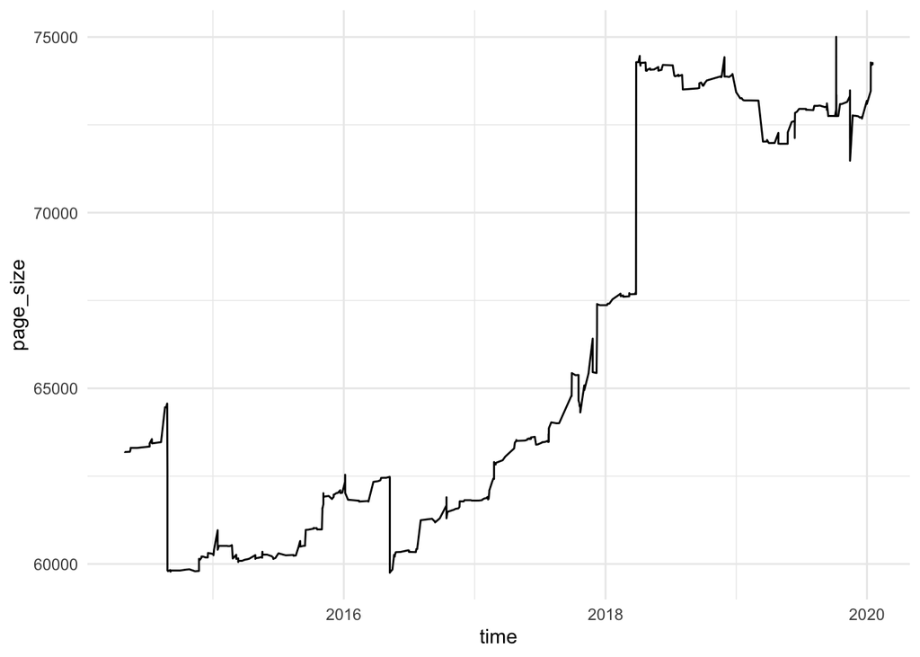

```r
page_revisions %>%
  filter(item %in% c("Apple")) %>%
  mutate(time = make_datetime(year, month, day, hour, minute, second)) %>%
  ggplot() +
    geom_line(aes(x = time, y = page_size))
```

We can see that there are a few very large edits (both deletions and additions), likely consisting of large sections added and substracted from the page. If we want to visualize when these large changes occur, it would be useful to include a more grainular set of labels on the x-axis. To do this, we use the layer `scale_x_datetime` and supply a string to describe the frequency of the labels. Here, we use a period of three months. The labels will start to get crowded here, so we will also add a `theme` layer to rotate the axis labels by 90 degrees.

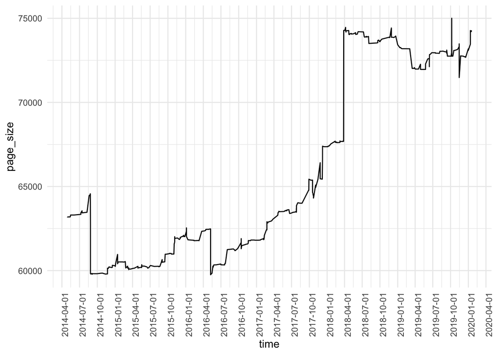

```r
page_revisions %>%
  filter(item %in% c("Apple")) %>%
  mutate(time = make_datetime(year, month, day, hour, minute, second)) %>%
  ggplot() +
    geom_line(aes(x = time, y = page_size)) +
    scale_x_datetime(date_breaks = "3 months") +
    theme(axis.text.x = element_text(angle = 90, hjust = 1))
```

We can also filter our dataset by a particular range of dates or times. This is useful to zoom into a specific region of our data to investigate patterns that may be otherwise lost. For example, if we wanted to see all of the page sizes for three food times from 2018 onwards, we can apply a filter function to take any data point that occurs after `make_datetime(2018)`.

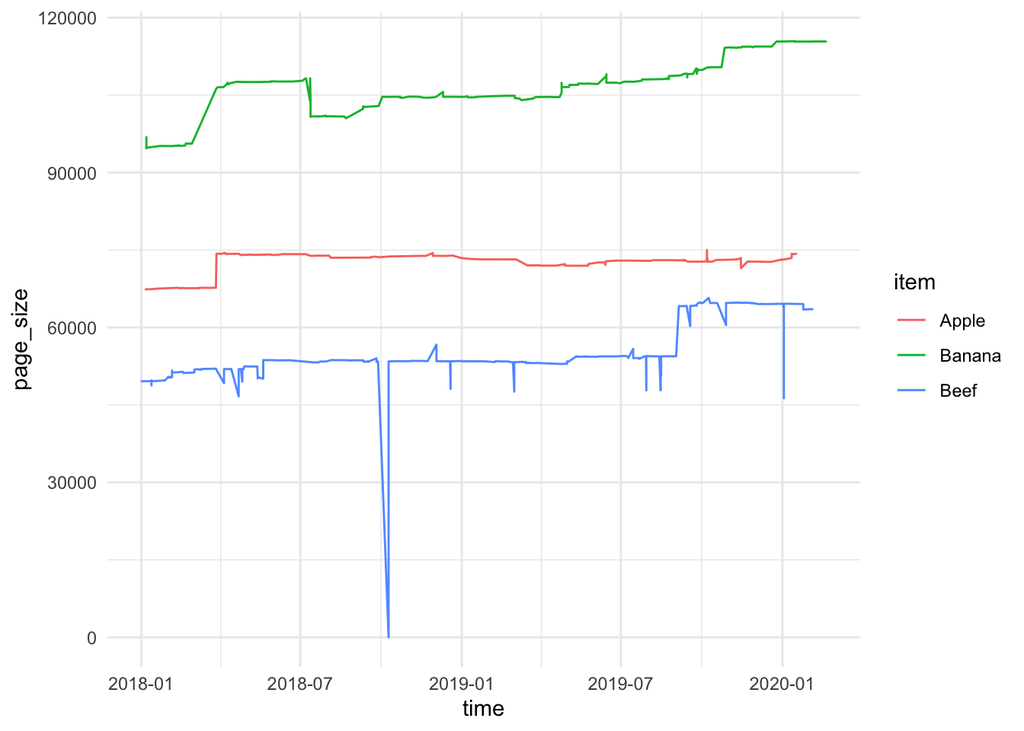

```r
page_revisions %>%
  filter(item %in% c("Apple", "Banana", "Beef")) %>%
  mutate(time = make_datetime(year, month, day, hour, minute, second)) %>%
  filter(time > make_datetime(2018)) %>%
  ggplot() +
    geom_line(aes(x = time, y = page_size, color = item))
```

Notice that the plot includes data from 2018, even though we use a strictly greater than, `>`, condition. The reason for this is that `make_datetime(2018)` is the exact time corresponding to 1 January 2018 at 00:00. Any record that comes at any other time during the year of 2018 will be included in the filter.

## Language and Timezones

```r
page_revisions %>%
  mutate(time = make_datetime(year, month, day, hour, minute, second)) %>%
  mutate(
    wday_en = wday(time, label = TRUE, abbr = FALSE, locale = "en_US.UTF-8"),
    wday_fr = wday(time, label = TRUE, abbr = FALSE, locale = "fr_FR.UTF-8"),
    wday_de = wday(time, label = TRUE, abbr = FALSE, locale = "de_DE.UTF-8"),
    wday_zh = wday(time, label = TRUE, abbr = FALSE, locale = "zh_CN.UTF-8"),
    wday_ru = wday(time, label = TRUE, abbr = FALSE, locale = "ru_RU.UTF-8"),
    wday_ja = wday(time, label = TRUE, abbr = FALSE, locale = "ja_JP.UTF-8"),
  ) %>%
  select(time, wday_en, wday_fr, wday_de, wday_zh, wday_ru, wday_ja)
```

```
## # A tibble: 30,415 x 7
##    time                wday_en  wday_fr wday_de    wday_zh wday_ru wday_ja
##    <dttm>              <ord>    <ord>   <ord>      <ord>   <ord>   <ord>
##  1 2020-01-16 18:05:15 Thursday Jeudi   Donnerstag 星期四  четверг 木曜日
##  2 2020-01-16 18:02:55 Thursday Jeudi   Donnerstag 星期四  четверг 木曜日
##  3 2020-01-14 14:48:14 Tuesday  Mardi   Dienstag   星期二  вторник 火曜日
##  4 2020-01-14 14:41:17 Tuesday  Mardi   Dienstag   星期二  вторник 火曜日
##  5 2020-01-11 15:54:42 Saturday Samedi  Samstag    星期六  суббота 土曜日
##  6 2020-01-11 15:22:05 Saturday Samedi  Samstag    星期六  суббота 土曜日
##  7 2020-01-11 15:21:41 Saturday Samedi  Samstag    星期六  суббота 土曜日
##  8 2020-01-11 10:53:30 Saturday Samedi  Samstag    星期六  суббота 土曜日
##  9 2020-01-11 10:17:43 Saturday Samedi  Samstag    星期六  суббота 土曜日
## 10 2019-12-31 16:29:19 Tuesday  Mardi   Dienstag   星期二  вторник 火曜日
## # … with 30,405 more rows
```

You can change the default language display by using the function `Sys.setlocale` before calling the date functions. For example, this function changes the default in R to use American English names for dates and times:

```r
Sys.setlocale("LC_TIME", "en_US.UTF-8")
```

```
## [1] "en_US.UTF-8"
```

You have probably noticed that I use a similar line of code at the top of each lab and project template. The reason for this is to better assist students in my classes who have computers set as a default to a different language. While I am generally in favor of using whatever language you are most comfortable with, it can be much more difficult for me (and I assume other instructors) to help students who have error messages in a language I do not understand. Also, the majority of websites offering technical advice operate in English. In general, you will have a much better chance of finding help by searching an English error message compared to another language.

Another regional issue that arises when working with dates and times are timezones. While seemingly not too difficult a concept, getting timezones to work correctly with complex datasets can be incredibly complicated. A wide range of programming bugs have been attributed to all sorts of edge-cases surrounding the processing of timezones.

All times stored in R are recorded using a fixed timezone called Coordinated Universal Time (UTC), which is roughly the time in London, England, but without adjustments for daylight savings time. The functions provided in **ggplot2** also default to showing data in UTC time, as do functions for writing datetimes as strings. Therefore, if you are only working with data from a single timezone, you can ignore this detail. While *technically* R thinks all of your times are relative to a specific timezone, this should have no practical significance. If, however, we have date recorded in different timezones, this detail is important.

All of the times recorded in the dataset `page_revisions` is given in UTC. This is not surprising; most technical sources with a global focus will use this convention. We do not know where each of the users who made page revisions lives, so there is no way to associate each edit with their local time. However, it may make sense to display information about time of day using the local time of a different location. For example, for an Audience in New York, displaying the hours in the local timezone could be helpful to reason about where and when edits are being made.

There are two functions for converting between timezones. The function `with_tz` gives a tag to a datetime variable that indicates how it should be displayed to the user and what local time should be used when extracting quantities such as days and hours. In order to use the function we need to understand how to describe a timezone. R uses a format that describes a timezone using the the format “continent/city”; we can see all of the available options using the function `OlsonNames`. Why this format? Continents are used in place of countries because the location of a city on a continent is relatively fixed, unlike the specific geopolitical borders that define a city. It also avoid many sensitive topics; everyone can agree that Taipei is in Asia. Cities are used because they change names very less frequently than countries and they (generally) have an agreed upon name in English. Local names for time zones are not great because they are not standardized. For example, there is an Eastern Standard Time in both the United States and in Australia. Here are the first 40 options:

```r
head(OlsonNames(), 40)
```

```
##  [1] "Africa/Abidjan"       "Africa/Accra"         "Africa/Addis_Ababa"
##  [4] "Africa/Algiers"       "Africa/Asmara"        "Africa/Asmera"
##  [7] "Africa/Bamako"        "Africa/Bangui"        "Africa/Banjul"
## [10] "Africa/Bissau"        "Africa/Blantyre"      "Africa/Brazzaville"
## [13] "Africa/Bujumbura"     "Africa/Cairo"         "Africa/Casablanca"
## [16] "Africa/Ceuta"         "Africa/Conakry"       "Africa/Dakar"
## [19] "Africa/Dar_es_Salaam" "Africa/Djibouti"      "Africa/Douala"
## [22] "Africa/El_Aaiun"      "Africa/Freetown"      "Africa/Gaborone"
## [25] "Africa/Harare"        "Africa/Johannesburg"  "Africa/Juba"
## [28] "Africa/Kampala"       "Africa/Khartoum"      "Africa/Kigali"
## [31] "Africa/Kinshasa"      "Africa/Lagos"         "Africa/Libreville"
## [34] "Africa/Lome"          "Africa/Luanda"        "Africa/Lubumbashi"
## [37] "Africa/Lusaka"        "Africa/Malabo"        "Africa/Maputo"
## [40] "Africa/Maseru"
```

Let’s create a new column in our dataset corresponding to the edit time but with the indication that times should be given relative to New York City. We will also extract the hours from the original time as well as the time relative to New York City and provide the difference between these two times.

```r
page_revisions %>%
  mutate(time = make_datetime(year, month, day, hour, minute, second)) %>%
  select(time) %>%
  mutate(time_nyc = with_tz(time, tzone = "America/New_York")) %>%
  mutate(hour_utc = hour(time), hour_nyc = hour(time_nyc)) %>%
  mutate(time_diff = time - time_nyc)
```

```
## # A tibble: 30,415 x 5
##    time                time_nyc            hour_utc hour_nyc time_diff
##    <dttm>              <dttm>                 <int>    <int> <drtn>
##  1 2020-01-16 18:05:15 2020-01-16 13:05:15       18       13 0 secs
##  2 2020-01-16 18:02:55 2020-01-16 13:02:55       18       13 0 secs
##  3 2020-01-14 14:48:14 2020-01-14 09:48:14       14        9 0 secs
##  4 2020-01-14 14:41:17 2020-01-14 09:41:17       14        9 0 secs
##  5 2020-01-11 15:54:42 2020-01-11 10:54:42       15       10 0 secs
##  6 2020-01-11 15:22:05 2020-01-11 10:22:05       15       10 0 secs
##  7 2020-01-11 15:21:41 2020-01-11 10:21:41       15       10 0 secs
##  8 2020-01-11 10:53:30 2020-01-11 05:53:30       10        5 0 secs
##  9 2020-01-11 10:17:43 2020-01-11 05:17:43       10        5 0 secs
## 10 2019-12-31 16:29:19 2019-12-31 11:29:19       16       11 0 secs
## # … with 30,405 more rows
```

Notice that R shows a different version of the time string for New York (here, five hours behind UTC) and also provides a different hour value of the hour variable. However, if we compute the time difference between the `time` and `time_nyc` variable R indicates that there are 0 seconds between these two times. Here, R thinks of the times as being the same, but with a different marker for how to print and extract other information (such as the hour) from the data. In this way it is similar to the `group_by` function, which also has no direct influence on the data but serves, rather, as an indicator to how other functions behave.

We can use the timezone variable, as mentioned above, to display information in a useful way to a local audience. For example, this code displays the frequency of updates as a function of the hour of the day in New York City.

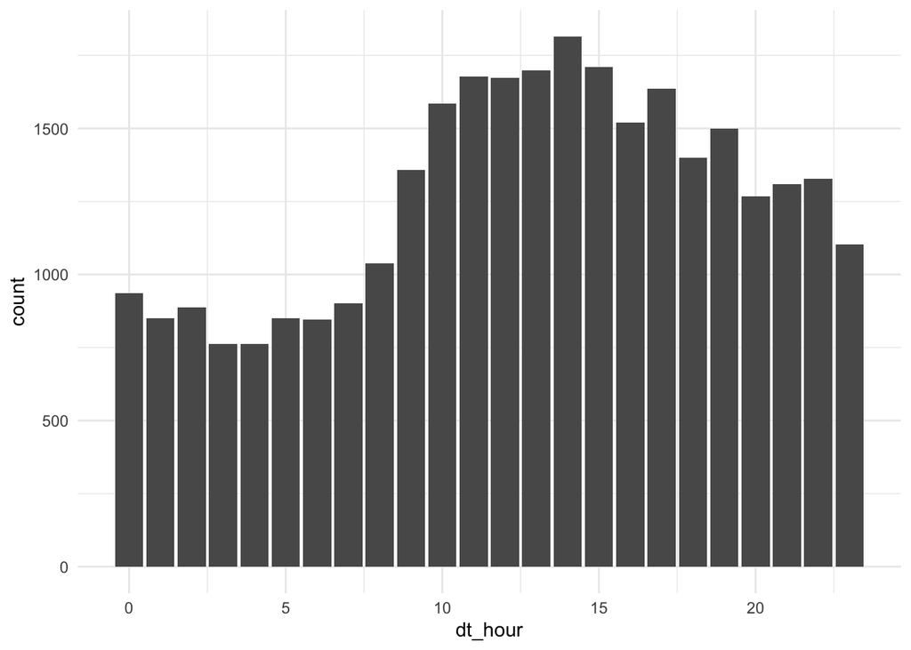

```r
page_revisions %>%
  mutate(time = make_datetime(year, month, day, hour, minute, second)) %>%
  select(item, time, page_size) %>%
  mutate(time_eastern = with_tz(time, tzone = "America/New_York")) %>%
  mutate(dt_hour = hour(time_eastern)) %>%
  group_by(dt_hour) %>%
  summarize(sm_count()) %>%
  ggplot() +
    geom_col(aes(dt_hour, count))
```

While certainly many editors are living in other English-speaking cities (London, Los Angeles, or Mumbai), it is generally easier for people to do the mental math for what times correspond with relative to their own timezone than relative to UTC.

The second function for manipulating timezoes in `force_tz`. Whereas `with_tz` assumes that datetimes were recorded correctly in UTC, the function `force_tz` indicates that a time was incorrectly recorded with a wrong timezone. With this function we are telling R that the time given is the time of the record in a different timezone. What if we replace the function `with_tz` above with `force_tz`?

```r
page_revisions %>%
  mutate(time = make_datetime(year, month, day, hour, minute, second)) %>%
  select(time) %>%
  mutate(time_nyc = force_tz(time, tzone = "America/New_York")) %>%
  mutate(hour_utc = hour(time), hour_nyc = hour(time_nyc)) %>%
  mutate(time_diff = time - time_nyc)
```

```
## # A tibble: 30,415 x 5
##    time                time_nyc            hour_utc hour_nyc time_diff
##    <dttm>              <dttm>                 <int>    <int> <drtn>
##  1 2020-01-16 18:05:15 2020-01-16 18:05:15       18       18 -5 hours
##  2 2020-01-16 18:02:55 2020-01-16 18:02:55       18       18 -5 hours
##  3 2020-01-14 14:48:14 2020-01-14 14:48:14       14       14 -5 hours
##  4 2020-01-14 14:41:17 2020-01-14 14:41:17       14       14 -5 hours
##  5 2020-01-11 15:54:42 2020-01-11 15:54:42       15       15 -5 hours
##  6 2020-01-11 15:22:05 2020-01-11 15:22:05       15       15 -5 hours
##  7 2020-01-11 15:21:41 2020-01-11 15:21:41       15       15 -5 hours
##  8 2020-01-11 10:53:30 2020-01-11 10:53:30       10       10 -5 hours
##  9 2020-01-11 10:17:43 2020-01-11 10:17:43       10       10 -5 hours
## 10 2019-12-31 16:29:19 2019-12-31 16:29:19       16       16 -5 hours
## # … with 30,405 more rows
```

Now, the times given in `time` and `time_nyc`, as well as the extracted hours, **look** the same, but R thinks that there is a difference of 5 hours between these two times.

## Window functions

At the start of this chapter, we considered time series to be a sequence of events without too much focus on the specific dates and times. This viewpoint can be a useful construct when we want to look at changes over time. For example, we have the overall size of each Wikipedia page after an edit. A measurement that would be useful is the *difference* in page size made by an edit. To add a variable to our dataset, we usually use the `mutate` function, and that will again work here. However, in this case we need to reference values that come before or after a certain value. This requires the use of window functions.

A window function transforms a variable in our dataset into a new variable with the same length, but unlike many other transformations takes into account the entire ordering of the data. Two examples of window functions that are useful when working with time series data are `lag` and `lead`, which give access to rows preceeding or following a row, respectively. Let’s apply this to our page revision dataset to get the previous and next values of the page size variable. The data are, as given, arranged in reverse chronological order. Before applying the window functions, we will reverse the ordering to more easily talk about the relationship between rows.

```r
page_revisions %>%
  mutate(time = make_datetime(year, month, day, hour, minute, second)) %>%
  arrange(item, time) %>%
  mutate(
    page_size_last = lag(page_size),
    page_size_next = lead(page_size)
  ) %>%
  select(item, time, page_size, page_size_last, page_size_next)
```

```
## # A tibble: 30,415 x 5
##    item  time                page_size page_size_last page_size_next
##    <chr> <dttm>                  <dbl>          <dbl>          <dbl>
##  1 Apple 2014-04-29 02:39:17     63192             NA          63188
##  2 Apple 2014-04-29 06:33:16     63188          63192          63194
##  3 Apple 2014-05-13 16:55:49     63194          63188          63259
##  4 Apple 2014-05-15 13:40:15     63259          63194          63304
##  5 Apple 2014-05-15 17:02:14     63304          63259          63304
##  6 Apple 2014-06-02 15:39:11     63304          63304          63343
##  7 Apple 2014-07-07 19:58:37     63343          63304          63432
##  8 Apple 2014-07-07 20:04:24     63432          63343          63554
##  9 Apple 2014-07-14 01:50:01     63554          63432          63432
## 10 Apple 2014-07-14 08:13:44     63432          63554          63468
## # … with 30,405 more rows
```

Notice that the first value of `page_size_last` is missing because there is no *last* value for the first item in our data. Similarly, the variable `page_size_next` will have a missing value at the end of the dataset. As written above, the code incorrectly crosses the time points at the boundary of each page. That is, for the first row of the second page (Asparagus) it thinks that the size of the last page is the size of the final page of the Apple record. To fix this, we can group the dataset by item prior to applying the window functions. Window functions respect the grouping of the data.

```r
page_revisions %>%
  mutate(time = make_datetime(year, month, day, hour, minute, second)) %>%
  arrange(item, time) %>%
  group_by(item) %>%
  mutate(
    page_size_last = lag(page_size),
    page_size_next = lead(page_size)
  ) %>%
  ungroup() %>%
  select(item, time, page_size, page_size_last, page_size_next) %>%
  slice(495:504)
```

```
## # A tibble: 10 x 5
##    item      time                page_size page_size_last page_size_next
##    <chr>     <dttm>                  <dbl>          <dbl>          <dbl>
##  1 Apple     2020-01-11 15:22:05     74265          74273          74204
##  2 Apple     2020-01-11 15:54:42     74204          74265          74230
##  3 Apple     2020-01-14 14:41:17     74230          74204          74204
##  4 Apple     2020-01-14 14:48:14     74204          74230          74263
##  5 Apple     2020-01-16 18:02:55     74263          74204          74204
##  6 Apple     2020-01-16 18:05:15     74204          74263             NA
##  7 Asparagus 2014-11-16 11:38:28     34421             NA          32802
##  8 Asparagus 2014-11-23 23:51:29     32802          34421          34421
##  9 Asparagus 2014-11-23 23:51:47     34421          32802          34507
## 10 Asparagus 2014-12-03 01:13:57     34507          34421          34421
```

Notice that now, correctly, the dataset has a missing `page_size_next` for the final Apple record and a missing `page_size_last` for the first Asparagus record. Now, let’s use this to compute the change in the page sizes for each of the revisions:

```r
page_revisions %>%
  mutate(time = make_datetime(year, month, day, hour, minute, second)) %>%
  arrange(item, time) %>%
  group_by(item) %>%
  mutate(
    page_size_diff = page_size - lag(page_size)
  ) %>%
  ungroup() %>%
  select(item, time, page_size, page_size_diff)
```

```
## # A tibble: 30,415 x 4
##    item  time                page_size page_size_diff
##    <chr> <dttm>                  <dbl>          <dbl>
##  1 Apple 2014-04-29 02:39:17     63192             NA
##  2 Apple 2014-04-29 06:33:16     63188             -4
##  3 Apple 2014-05-13 16:55:49     63194              6
##  4 Apple 2014-05-15 13:40:15     63259             65
##  5 Apple 2014-05-15 17:02:14     63304             45
##  6 Apple 2014-06-02 15:39:11     63304              0
##  7 Apple 2014-07-07 19:58:37     63343             39
##  8 Apple 2014-07-07 20:04:24     63432             89
##  9 Apple 2014-07-14 01:50:01     63554            122
## 10 Apple 2014-07-14 08:13:44     63432           -122
## # … with 30,405 more rows
```

In the above output, notice that one revision appears to completely revert another revision, by deleting the exact same number of bytes that were previously added. If we wanted to find these reversion in the dataset, we could apply the `lag` function several times. As an alternative, we can also give a parameter to `lag` (as well as `lead`) to indicate that we want to go back (or forward) more than one row. Let’s put this together to indicate which commits seem to be a reversion (the page size exactly matches the page size from two commits prior) as well as the overall size of the reversion.

```r
page_revisions %>%
  mutate(time = make_datetime(year, month, day, hour, minute, second)) %>%
  arrange(item, time) %>%
  group_by(item) %>%
  mutate(
    page_size_diff = page_size - lag(page_size),
    revision = (page_size == lag(page_size, 2))
  ) %>%
  ungroup() %>%
  select(item, time, page_size_diff, revision) %>%
  filter(revision)
```

```
## # A tibble: 6,609 x 4
##    item  time                page_size_diff revision
##    <chr> <dttm>                       <dbl> <lgl>
##  1 Apple 2014-07-14 08:13:44           -122 TRUE
##  2 Apple 2014-08-23 17:35:04              2 TRUE
##  3 Apple 2014-09-03 00:20:19            -31 TRUE
##  4 Apple 2014-09-03 00:34:25            -22 TRUE
##  5 Apple 2014-09-03 00:36:43            -31 TRUE
##  6 Apple 2014-12-17 03:44:24            -45 TRUE
##  7 Apple 2015-01-13 19:24:23           -555 TRUE
##  8 Apple 2015-03-06 17:32:42           -106 TRUE
##  9 Apple 2015-04-29 01:14:26           -106 TRUE
## 10 Apple 2015-05-08 07:02:27              5 TRUE
## # … with 6,599 more rows
```

We can study these reversions to see the nature of the Wikipedia editing processing. For example, how long do these reversions tend to take? Are certain pages more likely to undergo reversions? Do these take place during a certain time of the day?